# ROC

Andrei Guliaev

August 11, 2017

## Отбор данных

Нас интересуют колонки **Гестоз**, **PAPP-A (абс.)**, **PAPP-A (MoM)**, **ПИ**, **МАУ**.

0 и 1 в колонках *Гестоз* и *МАУ* (с 1-го по 96-е наблюдение) будут заменены на *нет* и *да* соответственно.

Данные до преобразования (первые 6 строк):

| Гестоз | PAPP.A | PAPP.A.MoM. | ПИ | МАУ |
| --- | --- | --- | --- | --- |
| 1 | 1589.46 | 0.60 | 2.98 | 1 |
| 1 | 1642.85 | 0.61 | 2.56 | 0 |
| 1 | 668.75 | 1.60 | 1.86 | 0 |
| 1 | 896.46 | 0.48 | 2.37 | 1 |
| 0 | 2363.59 | 1.04 | 1.24 | 0 |
| 0 | 2038.65 | 1.12 | 0.90 | 0 |

Данные после преобразования (первые 6 строк):

| Гестоз | PAPP.A | PAPP.A.MoM. | ПИ | МАУ |
| --- | --- | --- | --- | --- |
| да | 1589.46 | 0.60 | 2.98 | да |
| да | 1642.85 | 0.61 | 2.56 | нет |
| да | 668.75 | 1.60 | 1.86 | нет |
| да | 896.46 | 0.48 | 2.37 | да |
| нет | 2363.59 | 1.04 | 1.24 | нет |
| нет | 2038.65 | 1.12 | 0.90 | нет |

## Задача №1. ПЭ ~ PAPP-A * МАУ

Оценить совместное влияние PAPP-A и микроальбуминурии (МАУ) на развитие преэклампсии (Гестоз).

Поскольку данные о МАУ есть только для первых 96 наблюдений, выборка будет сокращена.

### Модель с взаимодействием предикторов (МАУ * PAPP-A):

```
##
## Call:
## glm(formula = Гестоз ~ PAPP.A * МАУ, family = "binomial",
##     data = data[1:96, ])
##
## Deviance Residuals:
##     Min       1Q   Median       3Q      Max
## -1.9543  -0.7057  -0.2566   0.6009   2.3279
##
## Coefficients:
##                 Estimate Std. Error z value Pr(>|z|)
## (Intercept)    2.302e-01  7.540e-01   0.305   0.7602
## PAPP.A        -6.479e-04  3.147e-04  -2.058   0.0396 *
## МАУода         2.210e+00  1.078e+00   2.050   0.0403 *
## PAPP.A:МАУода  5.122e-05  4.480e-04   0.114   0.9090
## ---
## Signif. codes:  0 '***' 0.001 '**' 0.01 '*' 0.05 '.' 0.1 ' ' 1
##
## (Dispersion parameter for binomial family taken to be 1)
##
##     Null deviance: 132.417  on 95  degrees of freedom
## Residual deviance:  88.756  on 92  degrees of freedom
## AIC: 96.756
##
## Number of Fisher Scoring iterations: 5
```

### Модель с взаимодействием предикторов (МАУ * PAPP-A (MoM)):

```
##
## Call:
## glm(formula = Гестоз ~ PAPP.A.MoM. * МАУ, family = "binomial",
##     data = data[1:96, ])
##
## Deviance Residuals:
##     Min       1Q   Median       3Q      Max
## -2.5168  -0.5314  -0.1589   0.2284   2.4217
##
## Coefficients:
##                    Estimate Std. Error z value Pr(>|z|)
## (Intercept)           2.874      1.451   1.980  0.04770 *
## PAPP.A.MoM.          -3.595      1.308  -2.749  0.00599 **
## МАУода                7.950      4.051   1.962  0.04971 *
## PAPP.A.MoM.:МАУода   -4.597      3.244  -1.417  0.15643
## ---
## Signif. codes:  0 '***' 0.001 '**' 0.01 '*' 0.05 '.' 0.1 ' ' 1
##
## (Dispersion parameter for binomial family taken to be 1)
##
##     Null deviance: 132.417  on 95  degrees of freedom
## Residual deviance:  59.454  on 92  degrees of freedom
## AIC: 67.454
##
## Number of Fisher Scoring iterations: 7
```

### Модель без взаимодействия предикторов (PAPPA.MoM + МАУ):

PAPP-A (MoM) выбран потому что при использованияя этих значений больше достоверных коэффициентов.

```
##
## Call:
## glm(formula = Гестоз ~ PAPP.A.MoM. + МАУ, family = "binomial",
##     data = data[1:96, ])
##
## Deviance Residuals:
##      Min        1Q    Median        3Q       Max
## -2.14823  -0.53296  -0.09816   0.39425   2.71610
##
## Coefficients:
##             Estimate Std. Error z value Pr(>|z|)
## (Intercept)   4.3726     1.3080   3.343 0.000829 ***
## PAPP.A.MoM.  -5.0224     1.2035  -4.173    3e-05 ***
## МАУода        2.5511     0.6879   3.709 0.000208 ***
## ---
## Signif. codes:  0 '***' 0.001 '**' 0.01 '*' 0.05 '.' 0.1 ' ' 1
##
## (Dispersion parameter for binomial family taken to be 1)
##
##     Null deviance: 132.417  on 95  degrees of freedom
## Residual deviance:  62.153  on 93  degrees of freedom
## AIC: 68.153
##
## Number of Fisher Scoring iterations: 6
```

### Вклад предикторов

Оценим достоверность вклада предикторов в модель без взаимодействия (МАУ + PAPP-A (MoM))

```
## Analysis of Deviance Table
##
## Model: binomial, link: logit
##
## Response: Гестоз
##
## Terms added sequentially (first to last)
##
##
##             Df Deviance Resid. Df Resid. Dev  Pr(>Chi)
## NULL                           95    132.417
## PAPP.A.MoM.  1   53.321        94     79.096 2.832e-13 ***
## МАУ          1   16.943        93     62.153 3.852e-05 ***
## ---
## Signif. codes:  0 '***' 0.001 '**' 0.01 '*' 0.05 '.' 0.1 ' ' 1
```

```
## Analysis of Deviance Table
##
## Model: binomial, link: logit
##
## Response: Гестоз
##
## Terms added sequentially (first to last)
##
##
##                 Df Deviance Resid. Df Resid. Dev  Pr(>Chi)
## NULL                               95    132.417
## PAPP.A.MoM.      1   53.321        94     79.096 2.832e-13 ***
## МАУ              1   16.943        93     62.153 3.852e-05 ***
## PAPP.A.MoM.:МАУ  1    2.698        92     59.454    0.1005
## ---
## Signif. codes:  0 '***' 0.001 '**' 0.01 '*' 0.05 '.' 0.1 ' ' 1
```

### Выбор лучшей модели

Однозначно выявить не удалось. Но будем считать, что это модель без взаимодействий, т.к. взаимодействие все равно не значимо, а AIC у двух моделей сопоставим.

```
## Analysis of Deviance Table
##
## Model 1: Гестоз ~ PAPP.A.MoM. * МАУ
## Model 2: Гестоз ~ PAPP.A.MoM. + МАУ
##   Resid. Df Resid. Dev Df Deviance Pr(>Chi)
## 1        92     59.454
## 2        93     62.153 -1  -2.6983   0.1005
```

## Задача №2. ПЭ ~ ПИ * МАУ

Оценить совместное влияние пульсационного индекса (ПИ) и микроальбуминурии (МАУ) на развитие преэклампсии (Гестоз)

```
##
## Call:
## glm(formula = Гестоз ~ ПИ * МАУ, family = "binomial",
##     data = data[1:96, ])
##
## Deviance Residuals:
##      Min        1Q    Median        3Q       Max
## -2.68960  -0.40131  -0.08768   0.23360   2.03987
##
## Coefficients:
##             Estimate Std. Error z value Pr(>|z|)
## (Intercept) -10.4987     3.0984  -3.388 0.000703 ***
## ПИ            5.1207     1.6389   3.124 0.001781 **
## МАУода        2.1481     4.4953   0.478 0.632758
## ПИ:МАУода     0.1163     2.5185   0.046 0.963160
## ---
## Signif. codes:  0 '***' 0.001 '**' 0.01 '*' 0.05 '.' 0.1 ' ' 1
##
## (Dispersion parameter for binomial family taken to be 1)
##
##     Null deviance: 132.417  on 95  degrees of freedom
## Residual deviance:  55.536  on 92  degrees of freedom
## AIC: 63.536
##
## Number of Fisher Scoring iterations: 7
```

Значимы только предикторы Intercept и PI.

Удалим из модели взаимодействие.

```
##
## Call:
## glm(formula = Гестоз ~ ПИ + МАУ, family = "binomial",
##     data = data[1:96, ])
##
## Deviance Residuals:
##      Min        1Q    Median        3Q       Max
## -2.67519  -0.40343  -0.08572   0.23822   2.04420
##
## Coefficients:
##             Estimate Std. Error z value Pr(>|z|)
## (Intercept) -10.5922     2.3670  -4.475 7.64e-06 ***
## ПИ            5.1706     1.2422   4.163 3.15e-05 ***
## МАУода        2.3532     0.7289   3.228  0.00124 **
## ---
## Signif. codes:  0 '***' 0.001 '**' 0.01 '*' 0.05 '.' 0.1 ' ' 1
##
## (Dispersion parameter for binomial family taken to be 1)
##
##     Null deviance: 132.417  on 95  degrees of freedom
## Residual deviance:  55.538  on 93  degrees of freedom
## AIC: 61.538
##
## Number of Fisher Scoring iterations: 6
```

Модель стала лучше и все предикторы значимы.

## Задача №3. ПЭ ~ PAPP-A (МоМ) * ПИ * МАУ

Оценить совместное влияние всех трех факторов (ПИ, МАУ, PAPP-A) на развитие ПЭ.

### Модель со взаимодействием всех предикторов.

```
##
## Call:
## glm(formula = Гестоз ~ PAPP.A.MoM. * ПИ * МАУ, family = "binomial",
##     data = data[1:96, ])
##
## Deviance Residuals:
##     Min       1Q   Median       3Q      Max
## -1.6415  -0.1993   0.0000   0.0000   2.0879
##
## Coefficients:
##                        Estimate Std. Error z value Pr(>|z|)
## (Intercept)          -7.888e+00  1.402e+01  -0.563    0.574
## PAPP.A.MoM.          -1.633e+00  1.133e+01  -0.144    0.885
## ПИ                    5.776e+00  7.529e+00   0.767    0.443
## МАУда                -1.790e+02  1.621e+05  -0.001    0.999
## PAPP.A.MoM.:ПИ       -7.734e-01  6.027e+00  -0.128    0.898
## PAPP.A.MoM.:МАУда    -1.840e+02  1.250e+05  -0.001    0.999
## ПИ:МАУда              2.564e+02  8.619e+04   0.003    0.998
## PAPP.A.MoM.:ПИ:МАУда -1.006e+01  5.781e+04   0.000    1.000
##
## (Dispersion parameter for binomial family taken to be 1)
##
##     Null deviance: 132.417  on 95  degrees of freedom
## Residual deviance:  27.815  on 88  degrees of freedom
## AIC: 43.815
##
## Number of Fisher Scoring iterations: 23
```

Все предикторы незначимы.

Исключаем взаимодействие PAPP-A (MoM) и ПИ

```
##
## Call:
## glm(formula = Гестоз ~ PAPP.A.MoM. + ПИ * МАУ, family = "binomial",
##     data = data[1:96, ])
##
## Deviance Residuals:
##      Min        1Q    Median        3Q       Max
## -1.83945  -0.22156  -0.03762   0.04965   2.42322
##
## Coefficients:
##             Estimate Std. Error z value Pr(>|z|)
## (Intercept)  -4.8205     3.6419  -1.324  0.18563
## PAPP.A.MoM.  -4.9334     1.5164  -3.253  0.00114 **
## ПИ            5.2863     1.9473   2.715  0.00663 **
## МАУода        1.3987     5.3709   0.260  0.79454
## ПИ:МАУода     0.6069     3.0537   0.199  0.84246
## ---
## Signif. codes:  0 '***' 0.001 '**' 0.01 '*' 0.05 '.' 0.1 ' ' 1
##
## (Dispersion parameter for binomial family taken to be 1)
##
##     Null deviance: 132.417  on 95  degrees of freedom
## Residual deviance:  36.704  on 91  degrees of freedom
## AIC: 46.704
##
## Number of Fisher Scoring iterations: 7
```

Исключаем все взаимодействия

```
##
## Call:
## glm(formula = Гестоз ~ PAPP.A.MoM. + ПИ + МАУ, family = "binomial",
##     data = data[1:96, ])
##
## Deviance Residuals:
##      Min        1Q    Median        3Q       Max
## -1.85747  -0.20911  -0.03767   0.06023   2.41002
##
## Coefficients:
##             Estimate Std. Error z value Pr(>|z|)
## (Intercept)  -5.3081     2.7881  -1.904 0.056929 .
## PAPP.A.MoM.  -4.8682     1.4593  -3.336 0.000850 ***
## ПИ            5.5105     1.6351   3.370 0.000751 ***
## МАУода        2.4527     0.9309   2.635 0.008417 **
## ---
## Signif. codes:  0 '***' 0.001 '**' 0.01 '*' 0.05 '.' 0.1 ' ' 1
##
## (Dispersion parameter for binomial family taken to be 1)
##
##     Null deviance: 132.417  on 95  degrees of freedom
## Residual deviance:  36.744  on 92  degrees of freedom
## AIC: 44.744
##
## Number of Fisher Scoring iterations: 7
```

Оставялем взаимодействие PAPP-A (MoM) и МАУ

```
##
## Call:
## glm(formula = Гестоз ~ PAPP.A.MoM. * МАУ + ПИ, family = "binomial",
##     data = data[1:96, ])
##
## Deviance Residuals:
##      Min        1Q    Median        3Q       Max
## -1.76878  -0.18564  -0.03496   0.02784   2.12446
##
## Coefficients:
##                    Estimate Std. Error z value Pr(>|z|)
## (Intercept)          -8.352      3.756  -2.224  0.02617 *
## PAPP.A.MoM.          -3.267      1.617  -2.020  0.04341 *
## МАУода                8.552      4.482   1.908  0.05639 .
## ПИ                    6.147      1.921   3.201  0.00137 **
## PAPP.A.MoM.:МАУода   -4.937      3.536  -1.396  0.16265
## ---
## Signif. codes:  0 '***' 0.001 '**' 0.01 '*' 0.05 '.' 0.1 ' ' 1
##
## (Dispersion parameter for binomial family taken to be 1)
##
##     Null deviance: 132.417  on 95  degrees of freedom
## Residual deviance:  34.082  on 91  degrees of freedom
## AIC: 44.082
##
## Number of Fisher Scoring iterations: 8
```

**Вывод:** все взамодействия незначимы. Лучшая модель со всеми предикторами это

Гестоз ~ PAPP-A (MoM) + ПИ + МАУ

## Задача № 4. Сравнение моделей.

Сравниваем три модели:

1. Гестоз ~ PAPP-A (MoM) + МАУ
2. Гестоз ~ ПИ + МАУ
3. Гестоз ~ ПИ + МАУ + PAPP-A (MoM)

```
## Analysis of Deviance Table
##
## Model 1: Гестоз ~ PAPP.A.MoM. + МАУ
## Model 2: Гестоз ~ ПИ + МАУ
## Model 3: Гестоз ~ PAPP.A.MoM. + ПИ + МАУ
##   Resid. Df Resid. Dev Df Deviance
## 1        93     62.153
## 2        93     55.538  0   6.6147
## 3        92     36.744  1  18.7941
```

Лучшая модель №3 Гестоз ~ PAPP-A (MoM) + ПИ + МАУ

Её формула выглядит так: $log(odds(Гестоз)) = -5.31 - 4.87*PAPP.A_{MoM} + 5.51*ПИ + 2.45*МАУ_{да}$

## Задача №5. ROC-анализ

Добавляем столбец с значениями ПЭ (Гестоз), предсказанными с помощью выбранной модели.

| Гестоз | PAPP.A | PAPP.A.MoM. | ПИ | МАУ | вероятность |
| --- | --- | --- | --- | --- | --- |
| да | 1589.46 | 0.60 | 2.98 | да | 0.9999762 |
| да | 1642.85 | 0.61 | 2.56 | нет | 0.9970679 |
| да | 668.75 | 1.60 | 1.86 | нет | 0.0547975 |
| да | 896.46 | 0.48 | 2.37 | да | 0.9996172 |
| нет | 2363.59 | 1.04 | 1.24 | нет | 0.0282484 |
| нет | 2038.65 | 1.12 | 0.90 | нет | 0.0030152 |

|  | Гестоз | PAPP.A | PAPP.A.MoM. | ПИ | МАУ | вероятность |
| --- | --- | --- | --- | --- | --- | --- |
| 91 | нет | 3368.70 | 1.43 | 1.75 | нет | 0.0674641 |
| 92 | да | 865.80 | 0.75 | 2.25 | да | 0.9972463 |
| 93 | да | 744.80 | 0.65 | 2.35 | да | 0.9990229 |
| 94 | да | 878.50 | 0.64 | 1.72 | нет | 0.7415909 |
| 95 | да | 1126.20 | 0.60 | 2.45 | да | 0.9995583 |
| 96 | да | 1052.57 | 1.04 | 2.15 | нет | 0.8140407 |

Оценим эффективность модели

### ROC-кривая.

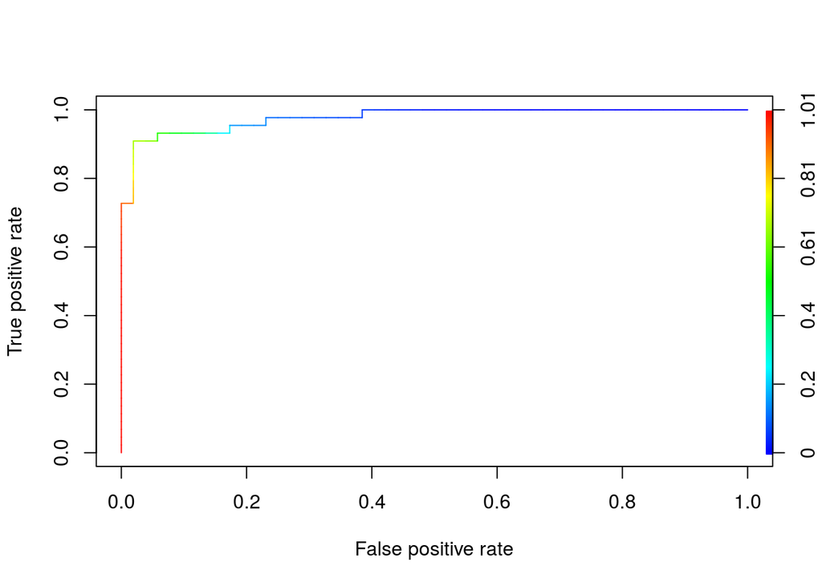

Значение AUC равно 0.98 (95% доверительный интервал: 0.953 - 1).

### Кривые специфичности, чувствительности и аккуратности выбранной модели

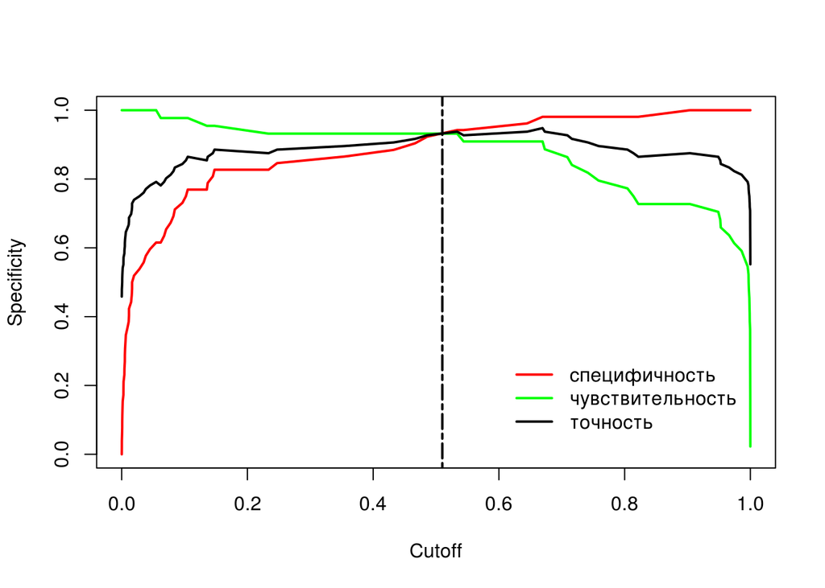

Вертикальная линия отмечает оптимальное пороговое значение вероятности (0.51) для выбранной модели.

### Точность предсказаний на графике

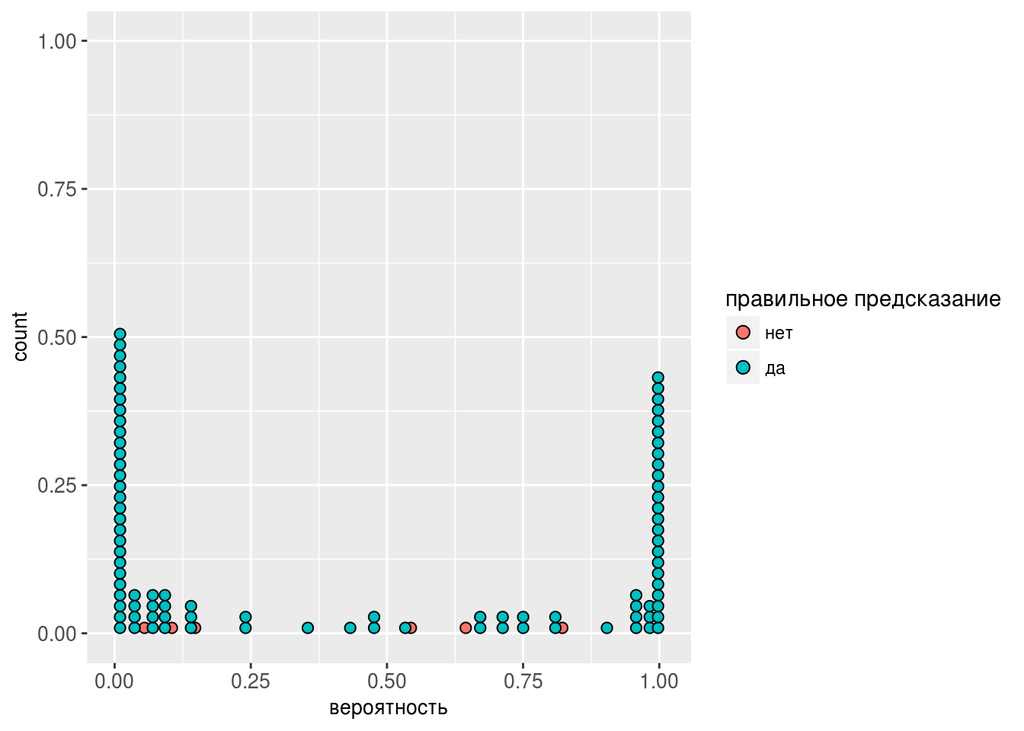

## Мозаичный график: сопряженность МАУ и гестоза

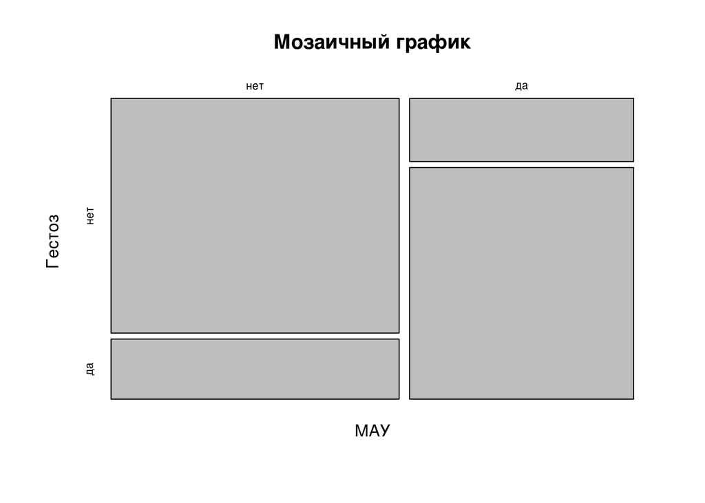

### тест Хи-квадрат

показывает, что присутствует взаимосвязь между МАУ и Гестозом

|  | stat | p.value | df |
| --- | --- | --- | --- |
| X-squared | 29.93273 | 0 | 1 |

Мозаичный график показывает, что наличие МАУ ассоциировано с гестозом

## Различия спедних в группах с гестозом и без него

### Пульсационный индекс

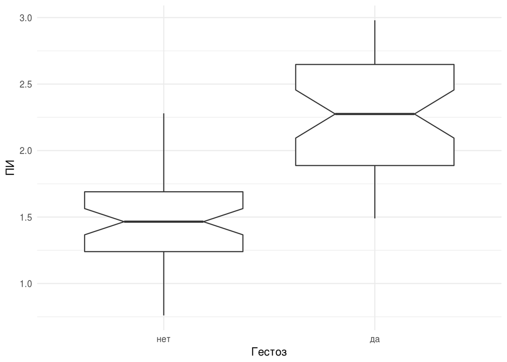

#### тест Краскела-Уоллеса

|  | stat | p.value | df |
| --- | --- | --- | --- |
| Kruskal-Wallis chi-squared | 49.73728 | 0 | 1 |

### Плазменный протеин PAPP.A (MoM)

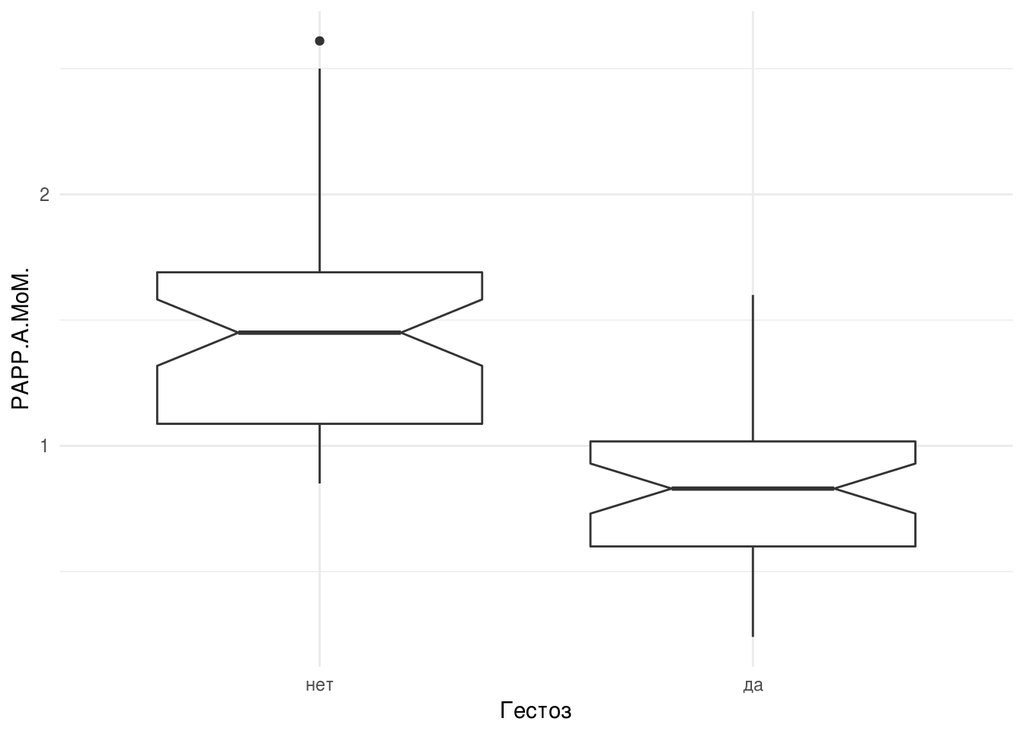

#### тест Краскела-Уоллеса

|  | stat | p.value | df |
| --- | --- | --- | --- |
| Kruskal-Wallis chi-squared | 43.4753 | 0 | 1 |

## Немного разведочного анализа данных

### Матрица графиков рассеяния

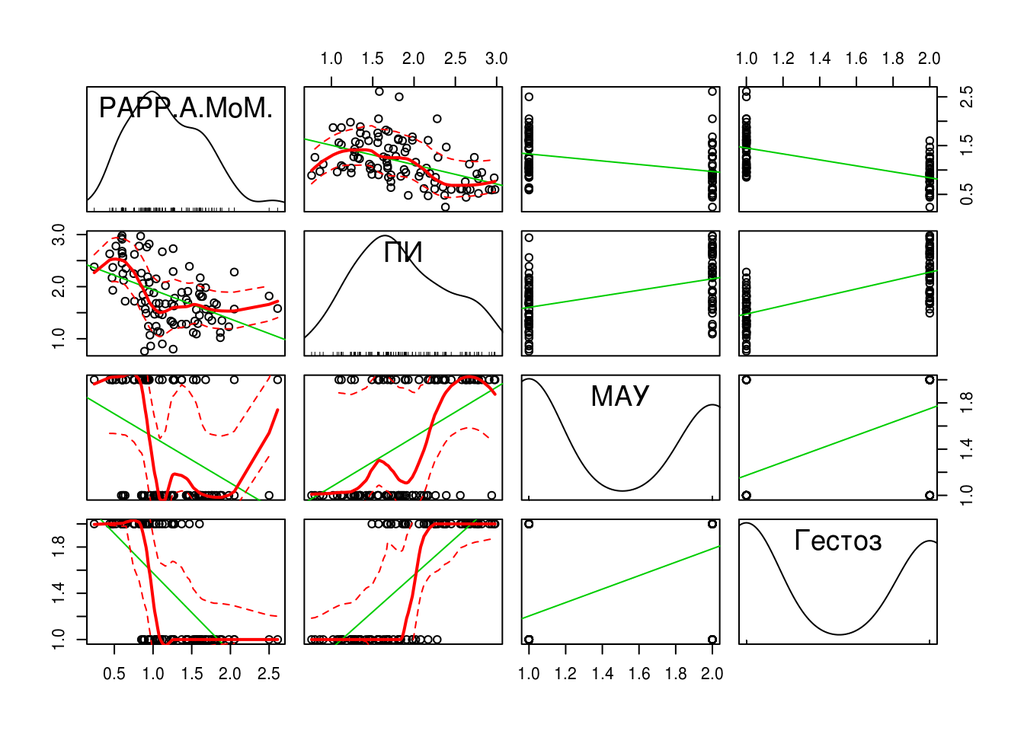

### График ядерной плотности: ПИ

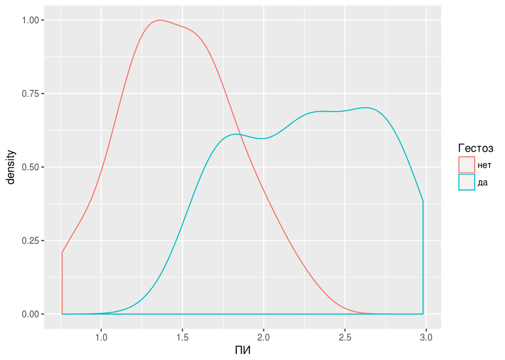

### График ядерной плотности: PAPPA.MoM

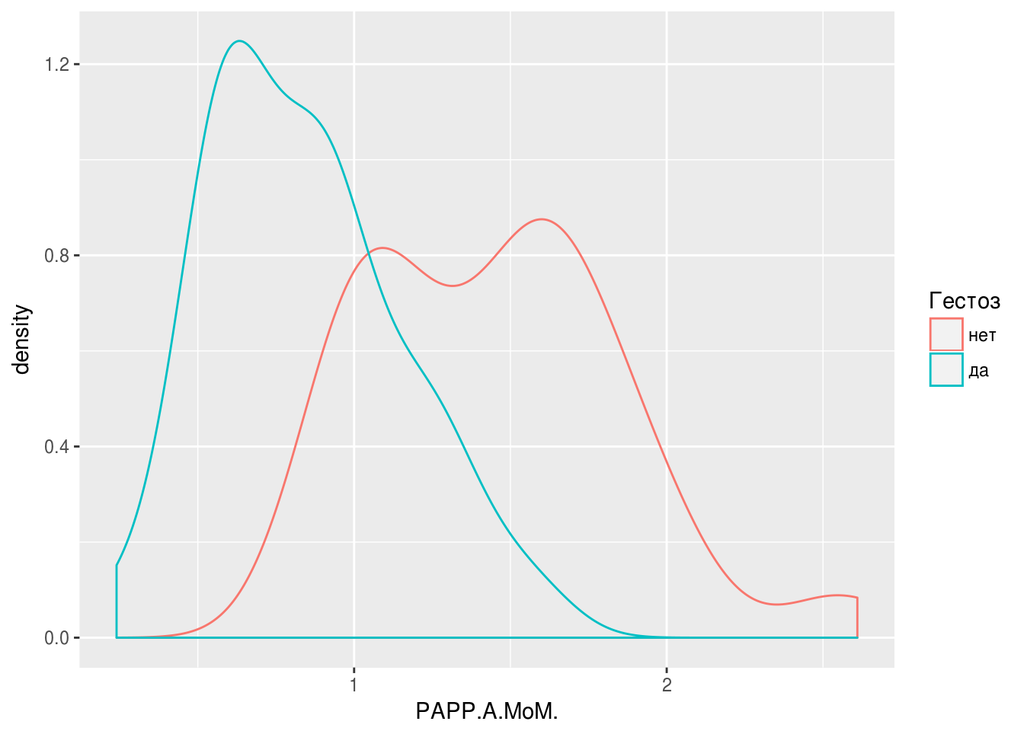

### График рассеяния + линии регрессии PAPPA.MoM~ПИ | МАУ

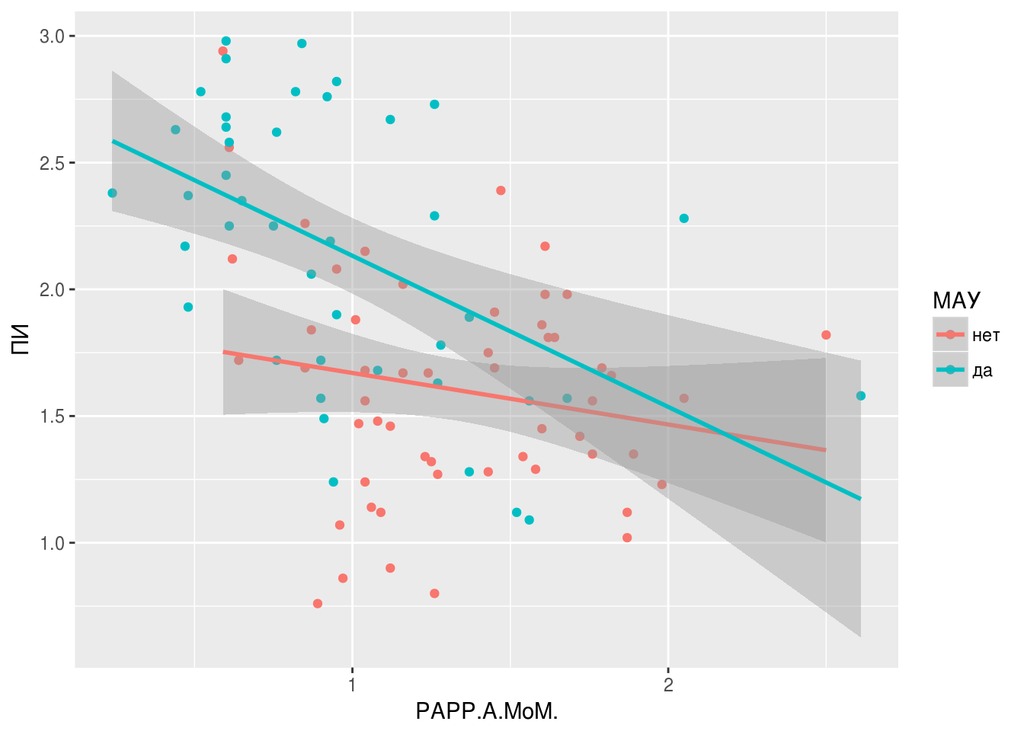

### График рассеяния + линии регрессии PAPPA.MoM~ПИ | Гестоз

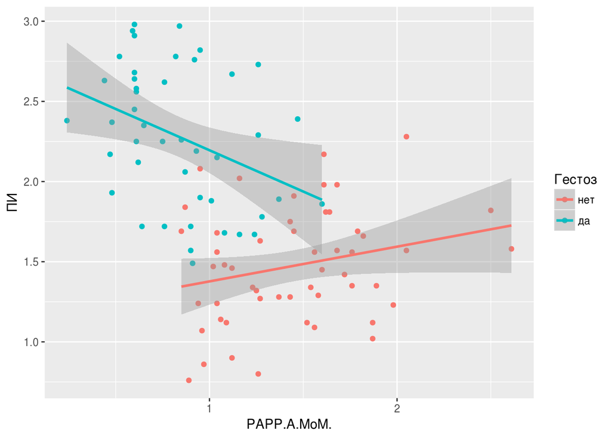

### График рассеяния + линия регрессии PAPPA.MoM~ПИ

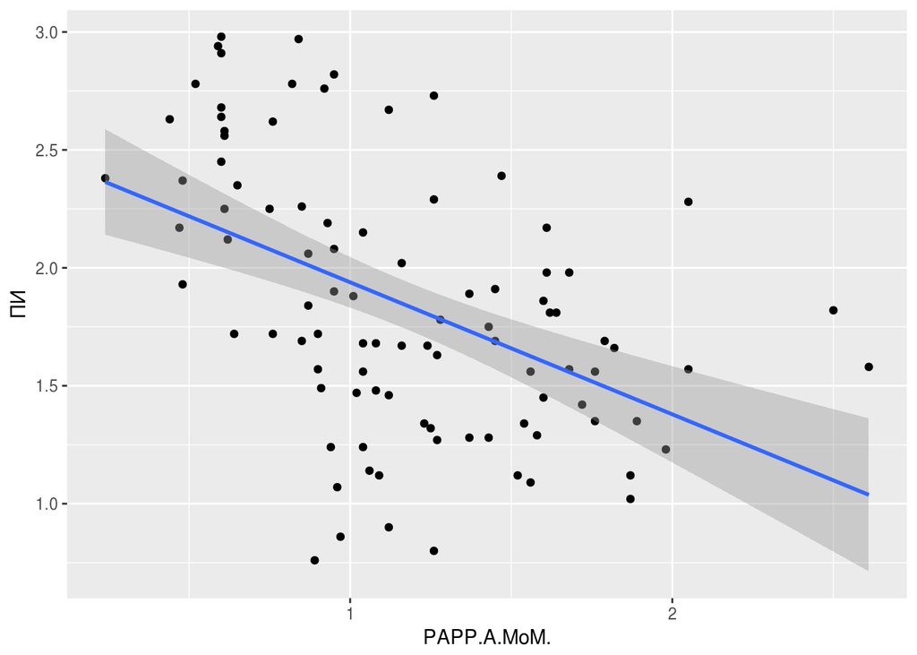

### PAPPA.MoM ~ PAPPA.Abs

#### график рассеяния

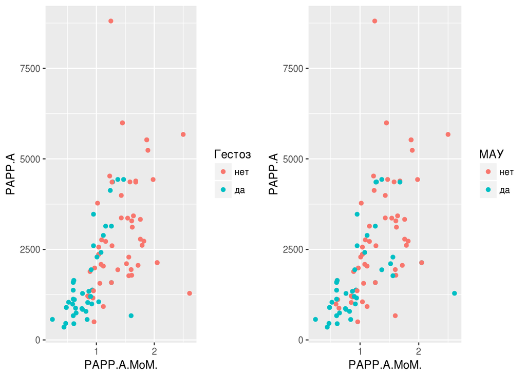

#### регрессия

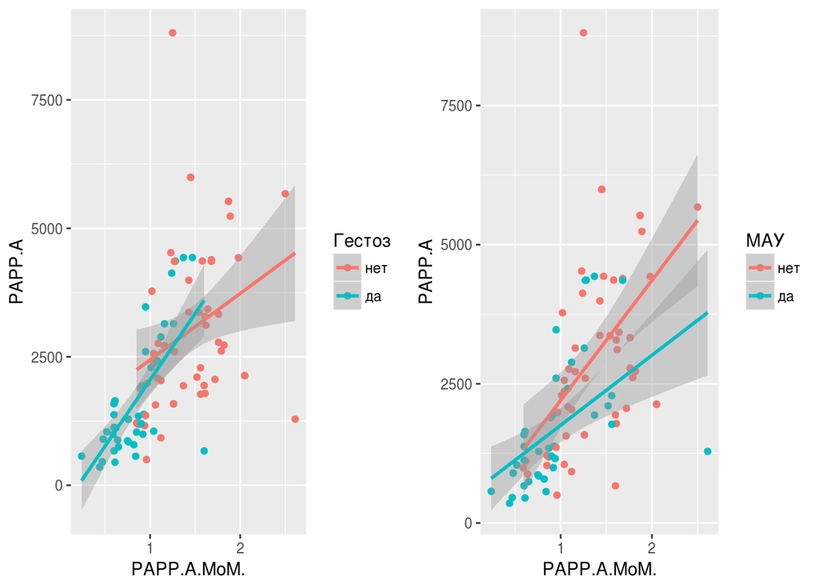

## Дополонительно

### Различия в средних значениях ПИ и PAPP-A(MoM) при разных срока реализации гестоза

#### ПИ ~ срок гестоза

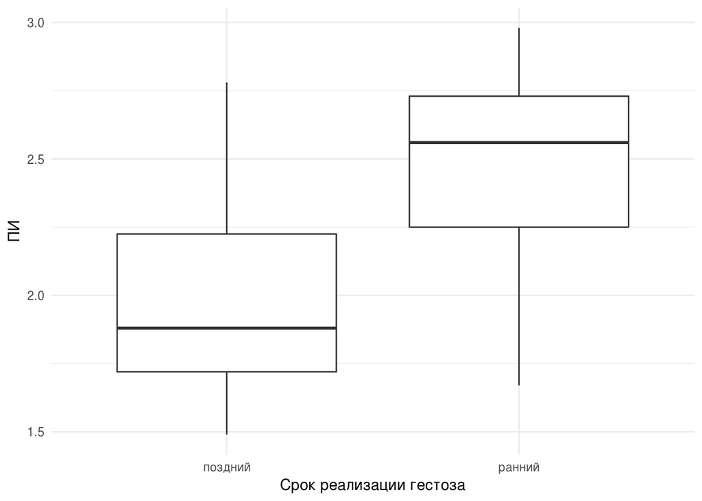

|  | stat | p.value | df |
| --- | --- | --- | --- |
| Kruskal-Wallis chi-squared | 11.72803 | 0.0006157 | 1 |

##### ПИ ~ срок гестоза (с доверительным интервалом)

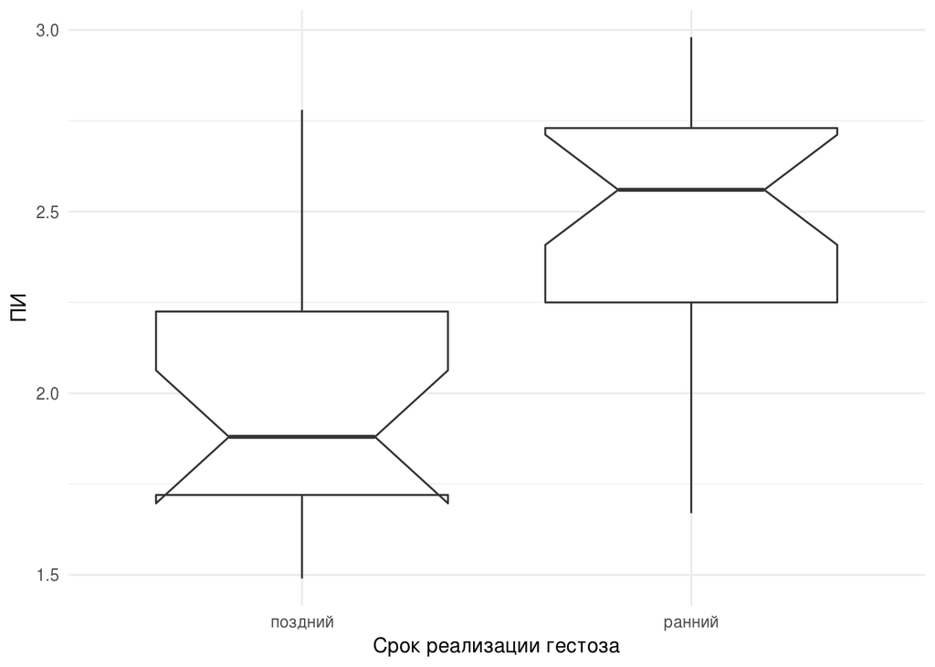

#### PAPP-A(MoM) ~ срок гестоза

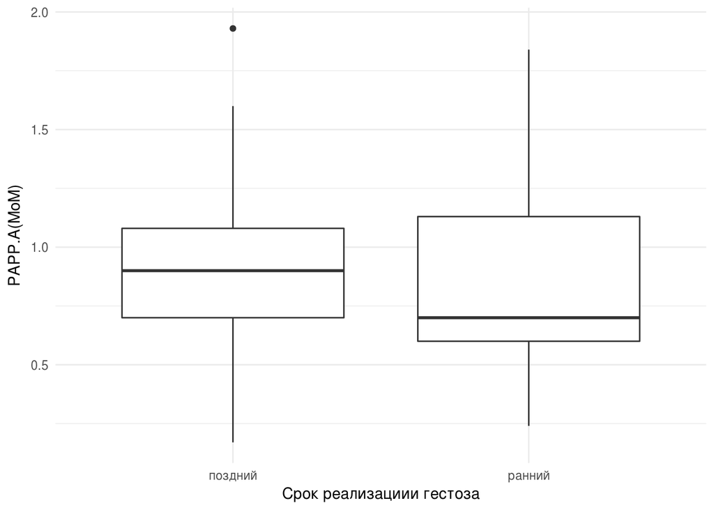

|  | stat | p.value | df |
| --- | --- | --- | --- |
| Kruskal-Wallis chi-squared | 2.95692 | 0.0855107 | 1 |

#### PAPP-A(MoM) ~ срок гестоза (с доверительным интервалом)

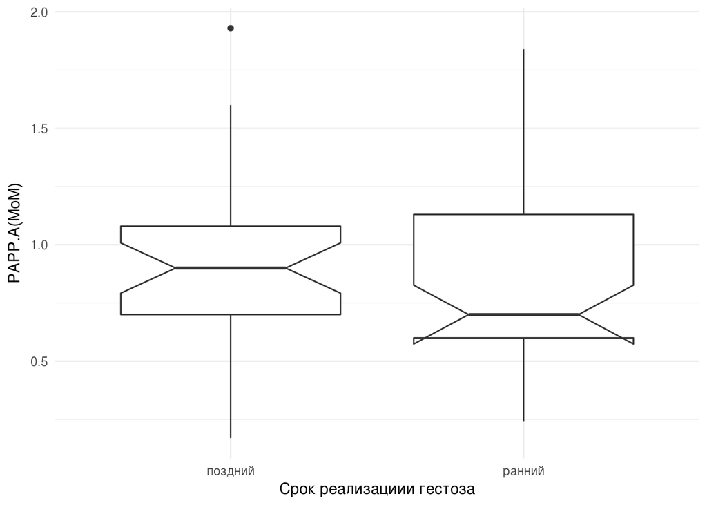